# eMOLT Weekly Update

*eMOLT Weekly Update 2023-03-17*

### Weekly Recap

Dr. Richard Spinrad (the head of NOAA) stopped by the lab in Woods Hole for a tour yesterday. He was excited to hear that we are working with the National Ocean Service to incorporate eMOLT data into more ocean forecast models. He also wanted to know if we’d ever thought about incorporating vessel-mounted weather stations into the eMOLT program. Those of you who’ve been around for a while might remember a series of proposals JiM wrote to get that kind of work funded. I believe there are still a few weather stations around from a proof-of-concept project, but maybe there’s some interest from the rest of NOAA in reviving that work? In the image below, JiM discusses weather station mounting with Jim Ford aboard the F/V Lisa Ann III back in 2019.

[figure not shown]

The 2023 drifter season got underway with a [link to plot](https://studentdrifters.org/tracks/drift_fpds_2023_1.html) deployment in the Gulf of Mexico. Erin Pelletier is working with the lead teacher to tell a very interesting story coming out soon concerning this one drifter. For now, you can download and view a [link to video](https://studentdrifters.org/tracks/drift_fpds_2023_1.mp4v) 3-minute deployment video relating part of the story. A few dozen more drifter deployments are planned this Spring on the Northeast Shelf. One was deployed by the USCG on 11 March in Cape Cod Bay [link to plot](https://studentdrifters.org/tracks/drift_fhs_2023_1.html), stranded on the Plymouth beaches four days later during the early stages of the Northeaster and recovered by a helpful beachwalker.

In less exciting news, the 2023 red tide sampling season is underway in Massachusetts, and DMF has implemented a shellfish harvest closure in parts of the Nauset estuary in Orleans and Eastham. For further information about specific areas impacted by the closure, please see the [full notice](https://www.mass.gov/doc/3823-psp-red-tide-closure-notice-for-the-harvest-of-all-shellfish-in-nauset-system/download). Red tides are [harmful algal blooms](https://oceanservice.noaa.gov/facts/redtide.html) the occur under specific environmental conditions, such as warm surface water, low salinity, and high nutrient availability. Even after the blooms recede, they may still cause additional problems for shellfish fisheries through the development of low-oxygen zones as the dead algae decompose.

George and Huanxin have been working closely with Joaquim from Lowell Instruments to improve the types of information we get back from the deckboxes on your boats. Information like the number of visible GPS satellites, how long the deckbox has been powered up, and when was the last time the deckbox tried to get data from a sensor are all valuable pieces of information that can help us be more efficient with troubleshooting. It’s not necessarily exciting news, but it’s progress nonetheless.

### Realtime Summary (Vessels with Rockblock Satellite Transmitters)

This week, we received 27 haul-averaged reports from 4 vessels.

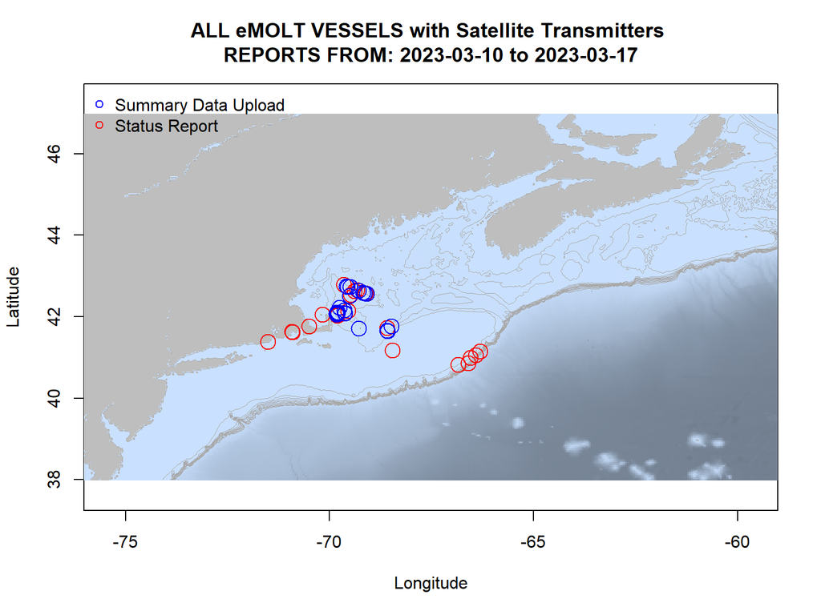

*Figure 3 - eMOLT Satellite Transmitter status plot for the previous week.*

In the figure above, you can see the approximate locations where we received “Status Reports” (a ping from your system letting us know that it’s still working) and “Data Uploads” (actual temperature / depth data collected by your probes). The “Status Reports” come in every 12 hours or so when a system is powered up. “Data Uploads” only come in when you haul the probes. If you were out fishing and don’t see your approximate locations on here, please reach out because there may be a problem with your system.

### Announcements

Glad to hear many of you were at the Maine Fishermen’s Forum. Sorry we missed it. Erin and George are planning to be at the Mass Lobstermen’s Weekend coming up, so hopefully we’ll catch up with some of you there. Maybe JiM will even make an appearance.

For those of you who missed the workshop at WHOI back in January, you can view the full recordings/videos at https://www.us-ocb.org/coastal-bgc-obs-network-with-fishing-community/. Just click on the blue “Watch Recordings” button.

All the best, George and JiM